# ReFUS C4 GBS K matrix and Index selection for paired plants

jim

April 14, 2018

Set working directory get libraries and import kinship matrix from tassel

```r
setwd("Q:/My Drive/GS_ReFUS_files/Predictions_2018_C4")
K = read.table("REFUSC3_4_join_imp_K.txt", stringsAsFactors = F, skip = 3)
line_names = K[,1]
K = as.matrix(K[,-1])
class(K) = "relationshipMatrix"
```

Fix the 17FL line names, which are exported from GBS pipeline with index information attached

```r
line_names = sub('^i[0-9]{2}_17FL', '17FL', line_names)
line_names = sub('_i[0-9]{2}$', '', line_names)
dimnames(K) = list(line_names, line_names)
```

Check the K elements overall

```r
summary(K)
```

```
##  dimension                     837 x 837
##  rank                          837
##  range of off-diagonal values  -0.402018 -- 1.059287
##  mean off-diagonal values      -0.001349344
##  range of diagonal values      0.6899 -- 1.661
##  mean diagonal values          1.128052
```

Separate the training and current data sets and check diagonal and off-diagonal elements of each

```r
train_index = grepl('1[25][FC]L', line_names)
new_index = grepl('17FL', line_names)
train_diag = diag(K[train_index, train_index])
summary(unclass(train_diag))
```

```
##    Min. 1st Qu.  Median    Mean 3rd Qu.    Max.
##  0.6899  0.9545  1.0320  1.0440  1.1120  1.6610
```

Summarize diagonal elements of new samples

```r
new_diag = diag(K[new_index, new_index])
summary(unclass(new_diag))
```

```
##    Min. 1st Qu.  Median    Mean 3rd Qu.    Max.
##  0.9239  1.1680  1.2730  1.2580  1.3570  1.5680
```

Compare the distribution of diagonal elements for the two sets

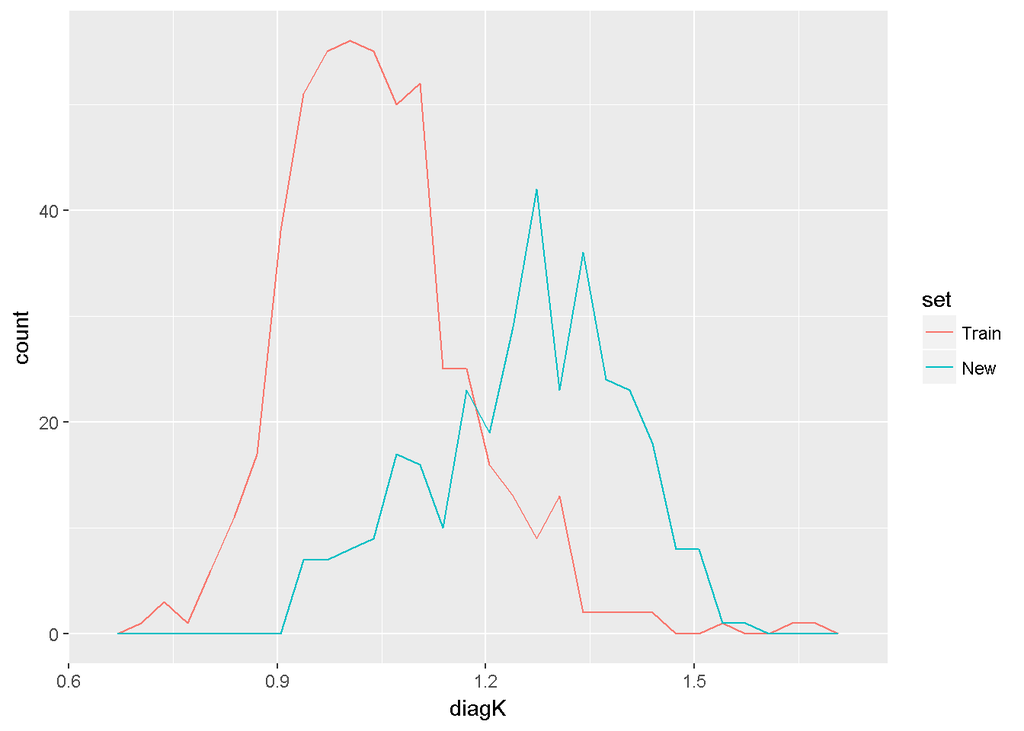

```r
Khistdf = data.frame(set = 'Train', diagK = unclass(train_diag))
Khistdf = rbind(Khistdf, data.frame(set = 'New', diagK = unclass(new_diag)))


histK = ggplot(Khistdf, aes(x = diagK)) + geom_freqpoly(aes(colour = set))
histK
```

The training set is based on S0:1 lines, so mean diagonal element is ~1.0. New data are individual S0 plants, so diagonal elements should also be around 1.0, but they are higher. I think this is because the new samples are from crosses among a small subset of individuals of the training, so this is drift leading to increased inbreeding in the new population relative to the original population.

Check how the new individuals are related to the original population according to marker profiles

```r
Kdist = 2 - K
diag(Kdist) = 0
mds = cmdscale(Kdist, k = 2, eig = T)

mds_df = data.frame(mds$points)
colnames(mds_df) = c("Dimension_1", "Dimension_2")
mds_df$line = line_names
mds_df$set = "Train"
mds_df[new_index,"set"] = "New"
```

Make a vector of the selected training S0:1 lines

```r
selected = c("12FL0006-3",
"12FL0012-7",
"12FL0022-5",
"15CL1032-12",
"15CL1029-7",
"12FL0002-6",
"12FL0005-2",
"15CL1030-3",
"15CL1023-5",
"15CL1039-15",
"15CL1030-17",
"15CL1027-13",
"15CL1039-11",
"15CL1009-17",
"12FL0003-5",
"12FL0007-2",
"12FL0011-4",
"12FL0024-14",
"15CL1040-1",
"15CL1040-17")

mds_df$selected = mds_df$line %in% selected
```

Plot the two sets via MDS

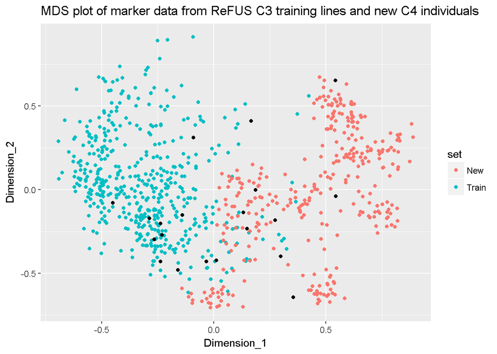

```r
mds_plot = ggplot(mds_df, aes(x = Dimension_1, y = Dimension_2)) +
  geom_point(aes(colour = set)) +
  geom_point(data = mds_df[mds_df$selected,], colour = 'black') +
  ggtitle("MDS plot of marker data from ReFUS C3 training lines and new C4 individuals")

mds_plot
```

Wow, selection in the last generation pushed the population strongly in the direction of the selected individuals.

Get the list of paired crosses that were made in 17FL winter nursery.

```r
pairs17FL = read.csv("Q:/My Drive/GS_ReFUS_files/Predictions_2018_C4/ReFUSC4_17FL_crosses.csv", stringsAsFactors = F)
```

Get the Gblups for ear rot and fumonisin from multivariate GBLUP model (‘model 11’)

```r
preds = read.table("Q:/My Drive/GS_ReFUS_files/Predictions_2018_C4/ReFUSC3-C4_Gblup_Model11.pvs", fill = T, stringsAsFactors = FALSE)
```

This is a mess, have to find which row starts the info we really want.

```r
header_index = which(preds[,1] == 'source_id')
footer_index = which(preds[,1] == 'SED:')
```

Extract the rows we want

```r
pred_values = preds[(header_index+1):(footer_index-1),]
colnames(pred_values) = unname(unlist(preds[header_index,]))
pred_values$Predicted_Value = as.numeric(pred_values$Predicted_Value)
pred_values$Standard_Error = as.numeric(pred_values$Standard_Error)
pred_values = pred_values[,c(1:5)] #get rid of extra columns with '' name, this messes up tidyr later
```

Extract the predictions from the ‘17FL’ samples. Spread the data frame to make two columns of predictions.(tidyr::spread is failing, I don’t know why)

```r
pred_values = select(pred_values, source_id, Trait, Predicted_Value)
Gblups = spread(pred_values, key = Trait, value = Predicted_Value) #fails

gblupsC4 = Gblups[grepl("^17FL", Gblups$source_id),]

gblupsC4$rot_blup_scaled = scale(gblupsC4$logear_rot)
gblupsC4$fum_blup_scaled = scale(gblupsC4$logfum)

gblupsC4$index = gblupsC4$rot_blup_scaled + gblupsC4$fum_blup_scaled
gblupsC4[order(gblupsC4$index),][1:30,]
```

```
##       source_id logear_rot logfum rot_blup_scaled fum_blup_scaled
## 562  17FL0106-8     2.1222 1.2798      -2.7995091      -2.0036169
## 841  17FL0131-9     2.1613 1.1896      -2.5628057      -2.2307411
## 546  17FL0105-5     2.2256 1.1849      -2.1735466      -2.2425758
## 614  17FL0111-3     2.1505 1.3996      -2.6281867      -1.7019596
## 703 17FL0119-13     2.3709 1.0312      -1.2939300      -2.6295935
## 638  17FL0113-3     2.2740 1.3369      -1.8805428      -1.8598386
## 566 17FL0107-11     2.2999 1.2762      -1.7237495      -2.0126817
## 851  17FL0133-4     2.2578 1.3835      -1.9786143      -1.7424995
## 764 17FL0125-10     2.2613 1.4050      -1.9574260      -1.6883623
## 662  17FL0115-2     2.2812 1.5083      -1.8369555      -1.4282521
## 720  17FL0120-8     2.5155 1.0054      -0.4185510      -2.6945581
## 540 17FL0105-10     2.3166 1.4851      -1.6226511      -1.4866699
## 700  17FL0119-1     2.2548 1.6728      -1.9967757      -1.0140399
## 701 17FL0119-10     2.2653 1.6490      -1.9332109      -1.0739685
```

[output cut: 47 more lines]

Now compute the selection index value for each pair of individuals (mean of their individual selection indices) in the new set (17FL C4 plants)

```r
Pair_GEBVs = merge(pairs17FL, gblupsC4, by.x = "Mother", by.y = "source_id", all.x = T)
#update the blup values to indicate they correspond to Mother plant
colnames(Pair_GEBVs)[7:11] = paste0(colnames(Pair_GEBVs)[7:11], "_Mom")

#Now merge with father blups
Pair_GEBVs = merge(Pair_GEBVs, gblupsC4, by.x = "Father", by.y = "source_id", all.x = T)
colnames(Pair_GEBVs)[12:16] = paste0(colnames(Pair_GEBVs)[12:16], "_Dad")
```

We compute a selection index that is the sum of the standardized blup for ear rot + standardized blup for fumonisin for each individual parent. Then we compute a breeding value for each pair (cross) as the average of the two parental blups.

We have a lot of pairs that have data on only one parent. The GEBV for such pairs is just the GEBV for the known parent. But we don’t have any information on relatedness of those pairs to each other or to other plants in the population, so they are not informative for computing effect on inbreeding coefficient.

I think the best we can do is to assume they have zero relationships and go on. But we should penalize the progeny BLUPs due to the fact that only one parent is predicted.

See Mrode p. 6 - 7 for prediction of individual with one vs. two parent’s data. beta (selection weight) is Cov(trueBV, y)/Var(y) . Here y is actually a gblup for one parent or mean of two parental gblups

Cov(trueBV,y) is the same for y = one parental BV vs y = mean of two parental BVs But Var(y) for one parent is sqrt(2)*Var(y mean) for mean of two parental BVs. So, we should penalize the predictions based on one parent only by multiplying the GBLUP by 1/sqrt(2)

```r
Pair_GEBVs$pair_index = rowMeans(Pair_GEBVs[, c("index_Mom", "index_Dad")], na.rm = T)
#create a Boolean that indicates if we have data on both parents
Pair_GEBVs$both_data = (! is.na(Pair_GEBVs$index_Mom) & ! is.na(Pair_GEBVs$index_Dad))

#total number of pairs harvested
print(paste ("Total pairs harvested: ", nrow(Pair_GEBVs)))
```

```
## [1] "Total pairs harvested:  211"
```

```r
#total number of pairs with data on both parents
print(paste ("Pairs with data on both parents: ", sum(Pair_GEBVs$both_data)))
```

```
## [1] "Pairs with data on both parents:  114"
```

```r
#number of pairs with data on only one parent
print(paste ("Pairs with data on only one parent: ", (nrow(Pair_GEBVs) - sum(Pair_GEBVs$both_data) - sum(is.na(Pair_GEBVs$pair_index)))))
```

```
## [1] "Pairs with data on only one parent:  82"
```

```r
Pair_GEBVs$pair_index_adj = ifelse(Pair_GEBVs$both_data, Pair_GEBVs$pair_index, Pair_GEBVs$pair_index/sqrt(2))
head(Pair_GEBVs)
```

```
##        Father      Mother            seed_ID    material gen
## 1  17FL0104-5  17FL0120-1  17FL0120-1×0104-5 ReFUS GS C5  S0
## 2  17FL0105-1 17FL0108-13 17FL0108-13×0105-1 ReFUS GS C5  S0
## 3 17FL0105-11  17FL0108-8 17FL0108-8×0105-11 ReFUS GS C5  S0
## 4 17FL0105-12  17FL0106-5 17FL0106-5×0105-12 ReFUS GS C5  S0
## 5 17FL0105-14  17FL0106-3 17FL0106-3×0105-14 ReFUS GS C5  S0
## 6 17FL0105-15  17FL0130-4 17FL0130-4×0105-15 ReFUS GS C5  S0
##                                    source_ID logear_rot_Mom logfum_Mom
## 1   (17CL0202-2×0202-7)×(17CL0189-2×0187-13)         2.5968     1.6740
## 2 (17CL0195-19×0196-2)×(17CL0191-11×0191-12)         2.6045     2.5044
## 3 (17CL0195-19×0196-2)×(17CL0191-11×0191-12)         2.3223     2.3534
## 4  (17CL0192-5×0192-8)×(17CL0191-11×0191-12)         2.8047     2.2901
## 5  (17CL0192-5×0192-8)×(17CL0191-11×0191-12)         2.4156     1.6735
## 6  (17CL0202-2×0202-7)×(17CL0191-11×0191-12)         2.4661     2.1643
##   rot_blup_scaled_Mom fum_blup_scaled_Mom  index_Mom logear_rot_Dad
```

[output cut: 20 more lines]

Code to compute reliabilities: #genetic variance of log ear rot from model 11 Vgr = 0.328141 #genetic variance of fum from model 11 Vgf = 0.976110 Pair_GEBVs$rot_reliab = sqrt(1 - (Pair_GEBVs$logear_rot_SEP/(1.5*Vgr))) Pair_GEBVs$fum_reliab = sqrt(1 - (Pair_GEBVs$fum_SEP/(1.5*Vgf)))

OK, now the hard part! Let’s first check the genomic relationship between each pair and exclude any pairs with Kij > 0.15 (0.25 is half sib relationship)

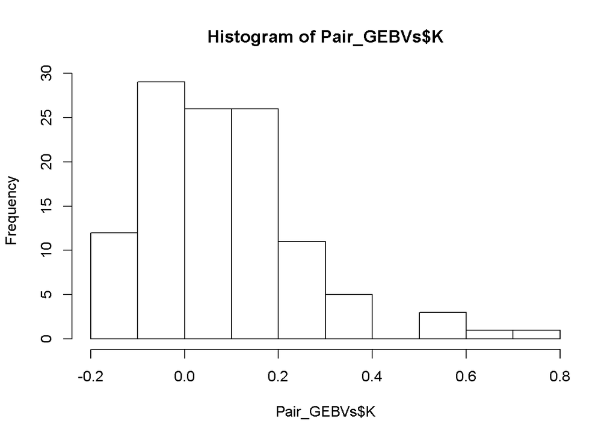

```r
pairwise_rel = function(row){
  #print(str(row))
  Mom = row['Mother']
  Dad = row['Father']
  #print(K[unclass(Mom), unclass(Dad)])
  if (Mom %in% rownames(K) & Dad %in% rownames(K)) {
    #return(K[unclass(Mom), unclass(Dad)])} else return(NA)
    return(K[Mom, Dad])} else return(NA)
}

#testing
#print(K["17FL0133-1", "17FL0133-4"])
#print(pairwise_rel(Pair_GEBVs[1,]))
#print(K["17CL0185-7", "17CL0185-14"])
#print(pairwise_rel(Pair_GEBVs[2,]))

#apply it
Pair_GEBVs$K = apply(Pair_GEBVs,1,FUN = pairwise_rel)
hist(Pair_GEBVs$K)
```

```r
summary(Pair_GEBVs$K)
```

```
##     Min.  1st Qu.   Median     Mean  3rd Qu.     Max.     NA's
## -0.17940 -0.03980  0.06354  0.08239  0.18260  0.70290       97
```

```r
#Any pairs with no known K value will be assigned K = 0
Pair_GEBVs[is.na(Pair_GEBVs$K), "K"] = 0

#How many will be excluded with K = 0.15 threshold?
print(nrow(Pair_GEBVs[!is.na(Pair_GEBVs$K) & Pair_GEBVs$K > 0.15,]))
```

```
## [1] 34
```

34 pairs will be excluded because of close relationships. Also remove pairs with no BV to include only eligible candidates

```r
eligible_pairs = Pair_GEBVs[Pair_GEBVs$K < 0.15 & ! is.na(Pair_GEBVs$pair_index_adj),]
```

Now let’s make a new K matrix that includes only 17FL plants and excludes pairs with close relationships. Use that to evaluate ‘optimal contribution’.

```r
Knew = K[new_index, new_index]
Newnames = unique(c(eligible_pairs$Mother, eligible_pairs$Father))
keepers = rownames(Knew) %in% Newnames
Knew2 = Knew[keepers, keepers]
print(str(K))
```

```
##  relationshipMatrix [1:837, 1:837] 1.1434 -0.0297 0.0335 0.0373 -0.0105 ...
##  - attr(*, "dimnames")=List of 2
##   ..$ : chr [1:837] "12FL0001-1" "12FL0001-2" "12FL0001-3" "12FL0001-4" ...
##   ..$ : chr [1:837] "12FL0001-1" "12FL0001-2" "12FL0001-3" "12FL0001-4" ...
## NULL
```

```r
print(str(Knew))
```

```
##  relationshipMatrix [1:329, 1:329] 1.382 0.678 0.757 0.678 0.65 ...
##  - attr(*, "dimnames")=List of 2
##   ..$ : chr [1:329] "17FL0104-1" "17FL0104-2" "17FL0104-3" "17FL0104-4" ...
##   ..$ : chr [1:329] "17FL0104-1" "17FL0104-2" "17FL0104-3" "17FL0104-4" ...
## NULL
```

```r
print(str(Knew2)) #this is smaller because we have individuals in Knew that did not make seed
```

```
##  relationshipMatrix [1:242, 1:242] 1.382 0.678 0.65 0.585 0.694 ...
##  - attr(*, "dimnames")=List of 2
##   ..$ : chr [1:242] "17FL0104-1" "17FL0104-2" "17FL0104-5" "17FL0104-7" ...
##   ..$ : chr [1:242] "17FL0104-1" "17FL0104-2" "17FL0104-5" "17FL0104-7" ...
## NULL
```

Now add the additional 17FL individuals, assuming they have 0 relationship with the others Add the extra names to the relationship matrix

```r
Knew3 = diag(1.5, nrow = length(Newnames), ncol = length(Newnames))
rownames(Knew3) = Newnames
colnames(Knew3) = Newnames
Knew3[rownames(Knew2), rownames(Knew2)] = Knew2
str(Knew3)
```

```
##  num [1:324, 1:324] 1.25594 -0.16366 0.00593 -0.03188 -0.12958 ...
##  - attr(*, "dimnames")=List of 2
##   ..$ : chr [1:324] "17FL0120-1" "17FL0108-13" "17FL0108-8" "17FL0106-5" ...
##   ..$ : chr [1:324] "17FL0120-1" "17FL0108-13" "17FL0108-8" "17FL0106-5" ...
```

# check that all the individuals in eligible pairs are also in Knew3 and vice versa

```r
identical(sort(Newnames), sort(rownames(Knew3))) #True
```

```
## [1] TRUE
```

```r
identical(sort(unique(c(eligible_pairs$Father, eligible_pairs$Mother))), sort(rownames(Knew3)))
```

```
## [1] TRUE
```

```r
identical(sort(Newnames), sort(rownames(Knew3)))
```

```
## [1] TRUE
```

```r
#paranoid double checking
all(eligible_pairs$Father %in% rownames(Knew3))
```

```
## [1] TRUE
```

```r
all(eligible_pairs$Mother %in% rownames(Knew3))
```

```
## [1] TRUE
```

```r
all(rownames(Knew3) %in% c(eligible_pairs$Father, eligible_pairs$Mother))
```

```
## [1] TRUE
```

Now make a function that computes the average breeding value and average inbreeding coefficient for a set of individuals sampled from the new population

```r
contribution = function(df, Kmat, selected_names){
  #df is a data frame like Pair_GEBVs or eligible_pairs that includes columns named:
  #Father
  #Mother
  #seed_ID
  #pair_index_adj
  #K is a relationship matrix with rownames including the set of Father, Mother names in the df
  #selected_names is a vector that includes a subset of seed_ID names

  #print(str(df))
  #print(str(Kmat))
  #print("inside contribution(), selected_names = ")
  #print(str(selected_names))
  #print("selected index value:")
  #print(df[df$seed_ID %in% selected_names, "pair_index_adj"])

  mean_BV = mean(df[df$seed_ID %in% selected_names, "pair_index_adj"])
  Kindexer = rownames(Kmat) %in% df[df$seed_ID %in% selected_names,"Mother"] | rownames(Kmat) %in% df[df$seed_ID %in% selected_names,"Father"]

  #genetic contribution of each line assumed equal = 1/N
  Kindexer = Kindexer/sum(Kindexer)
  inbreeding = t(Kindexer)%*%Kmat%*%Kindexer/2
  #print(list(mean_BV, inbreeding))
  return(list(mean_BV, inbreeding))

}

#testing
tryit = contribution(eligible_pairs, Knew3, eligible_pairs[order(eligible_pairs$pair_index_adj), "seed_ID"][1:25])
print(tryit)
```

```
## [[1]]
## [1] -1.773739
##
## [[2]]
##            [,1]
## [1,] 0.04817768
```

Make the objective function for use in kofnGA, objective function is MINIMIZED by best subset

Here since we want LOWER blups for rot and fumonisin, the mean blup index is a good criterion. But to restrict inbreeding, we will add a large number if inbreeding exceeds some criterion.

```r
OC_obj_fun = function(v, df, Kmat, maxInbr){
  selected_names = eligible_pairs[v, "seed_ID"] #select a subset of possible pairs
  #print(selected_names)
  BV_inbr = contribution(df, Kmat, selected_names)
  #print(BV_inbr)
  if (BV_inbr[[2]] > maxInbr){
    return(10000)} else return(BV_inbr[[1]])
}

tryOC = OC_obj_fun(1:10, eligible_pairs, Knew3, 0.05)
tryOC = OC_obj_fun(142:143, eligible_pairs, Knew3, 0.05)

print(tryOC)
```

```
## [1] 10000
```

Now implement the genetic algorithm for optimal subset search

```r
GA_05 = kofnGA(n = length(eligible_pairs$seed_ID), k = 10, OF = OC_obj_fun, ngen = 500, df = eligible_pairs, Kmat = Knew3, maxInbr = 0.05)
```

Get the summary

```r
summary(GA_05)
```

```
## Genetic algorithm search, 500 generations
## Number of unique solutions in the final population: 2
##
## Objective function values:
##                        average    minimum
## Initial population 8750.020631 -0.6316284
## Final population     -1.810425 -1.8114953
##
## Best solution (found at generation 60):
## 15 26 38 54 67 97 128 148 157 160
```

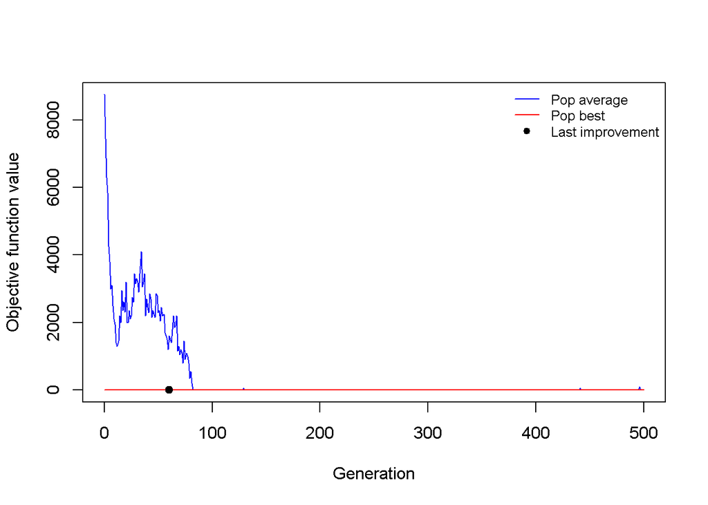

```r
plot(GA_05)
```

Get the vector of selected names - NOTE these are just the names of one of the two parents of each pair! Need to get the other parental names

```r
selected_crosses = eligible_pairs$seed_ID[GA_05$bestsol] #names of 10 selected crosses
selected_pairs = eligible_pairs[eligible_pairs$seed_ID %in% selected_crosses,]
write.csv(selected_pairs , file = "ReFUS_GS_C4 selected pairs.csv", row.names = F)
print(selected_crosses)
```

```
##  [1] "17FL0105-10×0107-16" "17FL0111-3×0108-5"   "17FL0122-2×0113-10"
##  [4] "17FL0130-3×0114-13"  "17FL0121-17×0116-3"  "17FL0104-11×0120-8"
##  [7] "17FL0117-7×0126-3"   "17FL0131-10×0130-6"  "17FL0105-16×0133-1"
## [10] "17FL0125-3×0133-3"
```

```r
print(selected_pairs)
```

```
##          Father      Mother             seed_ID    material gen
## 19  17FL0107-16 17FL0105-10 17FL0105-10×0107-16 ReFUS GS C5  S0
## 31   17FL0108-5  17FL0111-3   17FL0111-3×0108-5 ReFUS GS C5  S0
## 50  17FL0113-10  17FL0122-2  17FL0122-2×0113-10 ReFUS GS C5  S0
## 67  17FL0114-13  17FL0130-3  17FL0130-3×0114-13 ReFUS GS C5  S0
## 84   17FL0116-3 17FL0121-17  17FL0121-17×0116-3 ReFUS GS C5  S0
## 121  17FL0120-8 17FL0104-11  17FL0104-11×0120-8 ReFUS GS C5  S0
## 162  17FL0126-3  17FL0117-7   17FL0117-7×0126-3 ReFUS GS C5  S0
## 187  17FL0130-6 17FL0131-10  17FL0131-10×0130-6 ReFUS GS C5  S0
## 204  17FL0133-1 17FL0105-16  17FL0105-16×0133-1 ReFUS GS C5  S0
## 209  17FL0133-3  17FL0125-3   17FL0125-3×0133-3 ReFUS GS C5  S0
##                                      source_ID logear_rot_Mom logfum_Mom
## 19  (17CL0191-11×0191-12)×(17CL0195-8×0194-13)         2.3166     1.4851
## 31  (17CL0203-19×0203-18)×(17CL0195-19×0196-2)         2.1505     1.3996
## 50    (17CL0201-1×0204-13)×(17CL0204-4×0204-3)             NA         NA
```

[output cut: 40 more lines]

Now compare selected vs. whole population and vs. 10 best pairs selected for breeding value only in terms of breeding value and inbreeding coefficient

```r
TenBestBV = eligible_pairs[order(eligible_pairs$pair_index_adj), ][1:10,]
print(TenBestBV)
```

```
##          Father      Mother             seed_ID    material gen
## 103  17FL0117-9  17FL0105-5   17FL0105-5×0117-9 ReFUS GS C5  S0
## 110 17FL0119-10  17FL0112-9  17FL0112-9×0119-10 ReFUS GS C5  S0
## 19  17FL0107-16 17FL0105-10 17FL0105-10×0107-16 ReFUS GS C5  S0
## 58   17FL0113-4  17FL0120-9   17FL0120-9×0113-4 ReFUS GS C5  S0
## 57   17FL0113-3 17FL0129-10  17FL0129-10×0113-3 ReFUS GS C5  S0
## 50  17FL0113-10  17FL0122-2  17FL0122-2×0113-10 ReFUS GS C5  S0
## 204  17FL0133-1 17FL0105-16  17FL0105-16×0133-1 ReFUS GS C5  S0
## 75  17FL0115-13 17FL0120-11 17FL0120-11×0115-13 ReFUS GS C5  S0
## 187  17FL0130-6 17FL0131-10  17FL0131-10×0130-6 ReFUS GS C5  S0
## 31   17FL0108-5  17FL0111-3   17FL0111-3×0108-5 ReFUS GS C5  S0
##                                      source_ID logear_rot_Mom logfum_Mom
## 103 (17CL0191-11×0191-12)×(17CL0195-8×0194-13)         2.2256     1.1849
## 110 (17CL0201-1×0204-13)×(17CL0200-18×0201-13)         2.4411     1.8120
## 19  (17CL0191-11×0191-12)×(17CL0195-8×0194-13)         2.3166     1.4851
```

[output cut: 40 more lines]

Compare mean breeding values and inbreeding of whole population, set selected for optimal contribution, and set selected as best breeding values

```r
print("Breeding value and Expected Inbreeding of whole population")
```

```
## [1] "Breeding value and Expected Inbreeding of whole population"
```

```r
print(contribution(eligible_pairs, Knew3, eligible_pairs$seed_ID))
```

```
## [[1]]
## [1] 0.01411117
##
## [[2]]
##            [,1]
## [1,] 0.03010087
```

```r
print("Breeding value and Expected Inbreeding of pairs selected for optimal contribution")
```

```
## [1] "Breeding value and Expected Inbreeding of pairs selected for optimal contribution"
```

```r
print(contribution(eligible_pairs, Knew3, selected_pairs$seed_ID))
```

```
## [[1]]
## [1] -1.811495
##
## [[2]]
##            [,1]
## [1,] 0.04975611
```

```r
print("Breeding value and Expected Inbreeding of pairs selected for breeding value only")
```

```
## [1] "Breeding value and Expected Inbreeding of pairs selected for breeding value only"
```

```r
print(contribution(eligible_pairs, Knew3, TenBestBV$seed_ID))
```

```
## [[1]]
## [1] -2.063112
##
## [[2]]
##            [,1]
## [1,] 0.09029139
```

Finally, plot the selected individuals on the MDS plot

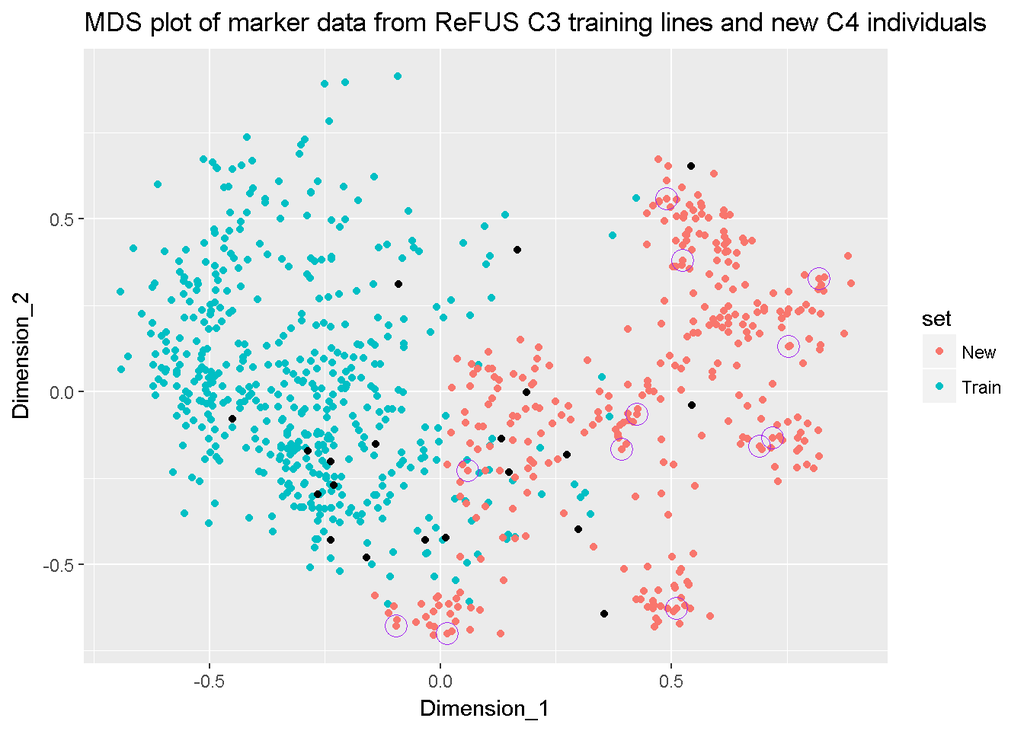

```r
mds2 = mds_df[mds_df$line %in% c(selected_pairs$Mother, selected_pairs$Father),]

mds_plot + geom_point(data = mds2, colour = 'purple', shape = 21, size = 5)
```